# CanvasLayer

# CanvasLayer renders children on a separate layer

You can think of `CanvasLayer` as a drawing layer in a painting program.

The `CanvasLayer` node defines a new rendering layer for its children. It has its own transform, so children don’t inherit the transforms of a parent viewport.

Also, `CanvasLayer` only affects the display of 2D and UI child nodes, as well as viewports (as they render their content to a 2D image). It doesn’t affect the drawing order of 3D objects directly.

In this guide, you will learn:

- How to set up a `CanvasLayer` and configure its attributes.
- How to make an interface fixed on the screen.
- How to render different layers in different orders.
- How to combine `CanvasLayer` and `ColorRect` nodes to apply post-processing and transition effects.

Contents:

- Setting up a CanvasLayer
- CanvasLayer’s key features
- How to use CanvasLayer in practice
  - Keeping the interface fixed on the screen
  - Pseudo-3D effect
  - Post-processing effects
  - Transition Effects
- Your Questions
  - Can I do parallax effects with CanvasLayer?
  - When should I use a ParallaxLayer over a CanvasLayer?
  - Lighting and CanvasLayer

## Setting up a CanvasLayer

Most of the time, setting up a `CanvasLayer` node consists of a few steps:

1. Add a `CanvasLayer` to your scene.
2. Set the *Layer* property.
3. Add children to the `CanvasLayer`.

You can create as many `CanvasLayer` instances as you want, one for each layer you want in your game.

## CanvasLayer’s key features

As each layer has its transform, you can use it to keep visuals fixed on the screen, like a heads-up display.

You can also use it to fake parallax by moving the background and foreground at different speeds to give the game world some depth.

Note, though, that Godot has a dedicated node for that: `ParallaxLayer`.

There are three main properties we need to know to use a `CanvasLayer` properly:

1. The *Layer* property defines the rendering order. `CanvasLayer` nodes with a higher *Layer* number render above those with a lower *Layer* number. The game’s root viewport is on layer `0`.
2. Enabling the *Follow Viewport -> Enable* property makes the layer follow the viewport, scrolling with the parent viewport’s camera.
3. The *Follow Viewport -> Scale* property controls the layer’s scale when *Follow Viewport -> Enable* is enabled. The higher the scale, the faster the layer pans with the view. Use a scale greater than `1` for foreground layers and lower than `1` for backgrounds.

Note: you can learn more about viewports in the Viewport guide.

## How to use CanvasLayer in practice

Let’s now see how you can use the node in practice in your projects.

### Keeping the interface fixed on the screen

Whenever you want some interface or visual effect always to be visible and stick to the screen, use a `CanvasLayer`.

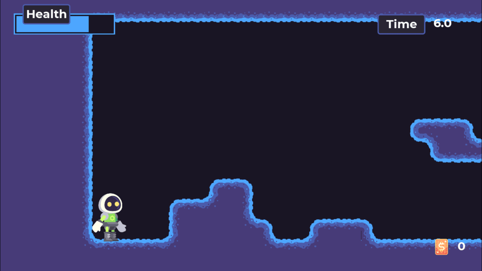

To do so, all it takes is nesting under a `CanvasLayer`:

1. Add a `CanvasLayer` node to the scene.
2. In the *Inspector*, set its *Layer -> Layer* to a value higher than any other `CanvasLayer` in the scene.

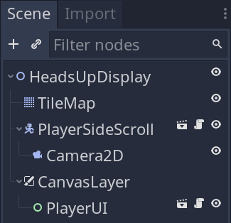

hud-scene

By default, *Follow Viewport -> Enable* is turned off, so the layer doesn’t follow the parent viewport: even when the player moves, the interface stays in place.

### Pseudo-3D effect

Godot has `ParallaxBackground` and `ParallaxLayer` nodes to make the foreground and background scroll at a different speed from the player’s plane, helping give the illusion of depth in your game.

The `CanvasLayer` allows you to fake a 3D effect in side-scrolling games with its *Follow Viewport -> Scale* property.

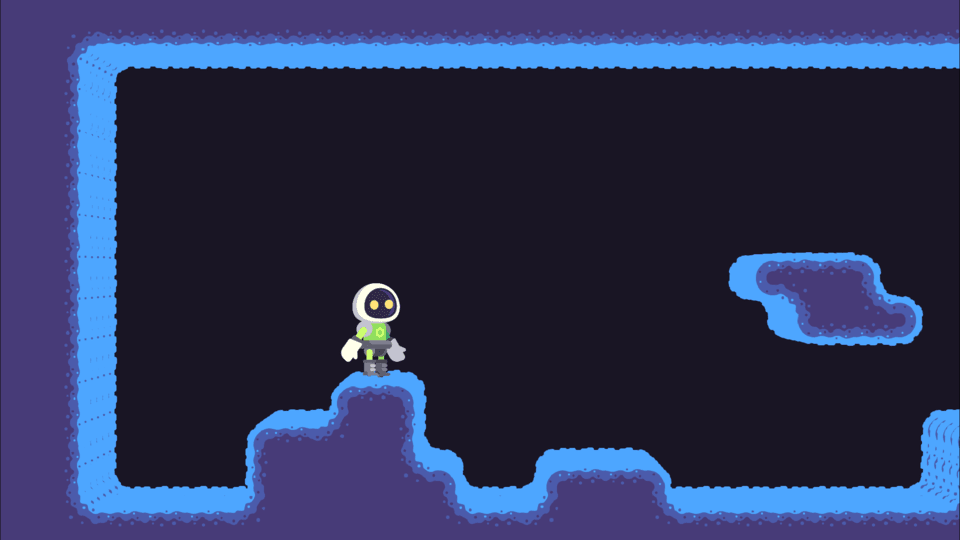

To achieve this effect, you need to duplicate your game’s playable area into several layers and play with the layers’ scales.

While you could do it by hand, it’d be slow and tedious. Here’s how to use code to generate new layers and create that pseudo-3D effect automatically.

In this example, our scene includes a tilemap and a character that can move and jump.

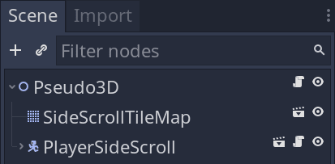

The *Pseudo3D* node has the following code attached to it:

```
extends Node2D

## The number of layers we want to generate.
export var layer_count := 6
## The extra offset we apply to each layer's `follow_viewport_scale`.
## The hint in parentheses makes the Inspector limit the value's range between
## 0.01 and 0.2.
export (float, 0.01, 0.2) var scale_offset := 0.04

onready var _tilemap: TileMap = $TileMap


func _ready():
    # We create `layer_count` canvas layers and set them up in a loop.
    for index in range(layer_count):
        var canvas := CanvasLayer.new()
        # We place half the layers in front of the player, and half behind behind.
        # That way, the character appears in the middle of the ground.
        canvas.layer = layer_count / 2 - index
        # This prevents having a CanvasLayer on layer `0`, which would be the
        # same as the viewport.
        if canvas.layer == 0:
            canvas.layer += 1

        # We make the layer follow the viewport and scale it using `scale_offset`.
        canvas.follow_viewport_enable = true
        canvas.follow_viewport_scale = 1.0 + canvas.layer * scale_offset
        add_child(canvas)

        # We duplicate our game's ground and add it as a child of the new layer,
        # which will scale it up or down, producing this 3D feel.
        canvas.add_child(_tilemap.duplicate())
```

To preview the effect in the editor, you can add the `tool` keyword at the top of the script. You’ll need to close and reopen the scene for the code to run.

Then, turn on *View -> Preview Canvas Scale* in the toolbar.

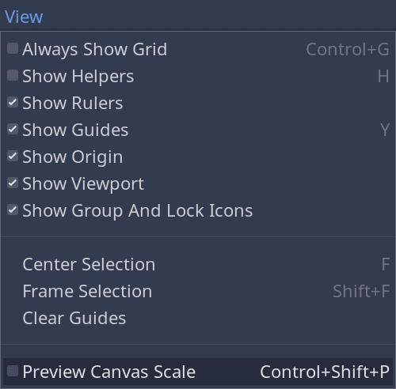

You should see the layers in the 2D viewport.

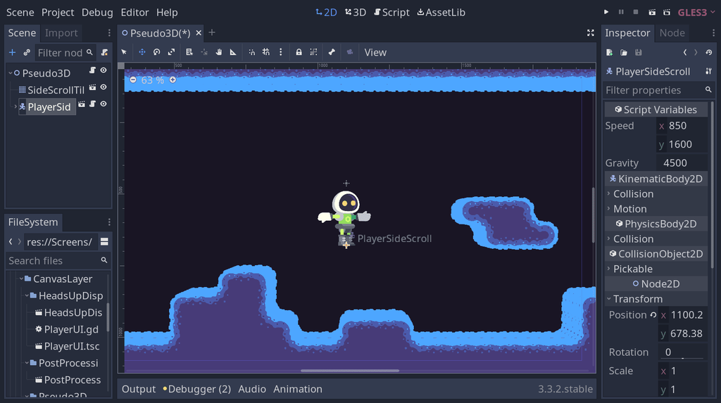

Here, we generated the layers from the code. Technically, you could place them by hand, but that’d only take you more time to set up and tweak.

To add more depth to your game world and get more control over each layer’s scroll speed, you’ll want to use the `ParallaxLayer` node instead.

### Post-processing effects

Using a `CanvasLayer` and a `ColorRect`, you can apply post-processing effects to the entire screen, like:

- Pixelating the screen for a combat transition animation.
- Making the screen glitch in a sci-fi game.

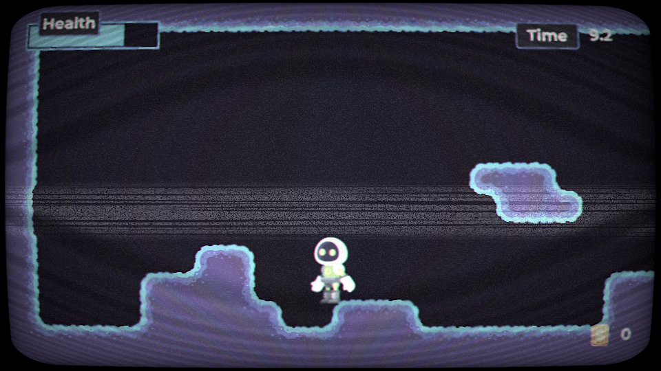

All you need is to add a screen-reading shader to the `ColorRect`.

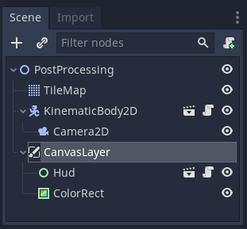

hud-scene

To do so, you select the `ColorRect` node and assign a new `ShaderMaterial` to its *Material -> Material* property (down under the *Visibility* category).

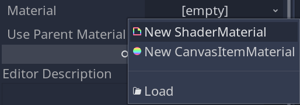

Then, you want to expand the material and assign a `Shader` or `VisualShader` resource to its *Shader* property.

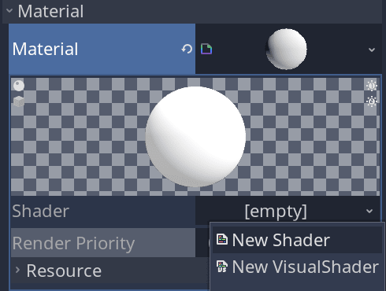

In this example, we used this [shader](https://godotshaders.com/shader/vhs-and-crt-monitor-effect/) to give the whole screen a Cathode Ray Tube (CRT) TV look.

**Note:** Shader programming is a deep topic. To learn more about shader creation, check out the following resources on shaders:

- The [Book of Shaders](https://thebookofshaders.com/) is a general free resource to get you started with shader creation.
- We made a free tutorial series to [get started with shaders in Godot](https://www.gdquest.com/tutorial/godot/shaders/introduction/chapter/6-water-shadow-and-masking/).
- If you want to go further, you might be interested in our course [Godot Shader Secrets](https://gdquest.mavenseed.com/courses/godot-shader-secrets) (paid).

### Transition Effects

Transition effects are a particular case of post-processing effects. As such, the setup is the same as in the previous example.

You can make a simple transition effect using a `CanvasLayer` with a `ColorRect` child and an `AnimationPlayer` to control the color of the `ColorRect` to achieve a fade-to-black effect. We covered this in the AnimationPlayer guide.

## Your Questions

### Can I do parallax effects with CanvasLayer?

When the background pans at a different speed from the foreground in a game, we call that effect parallax. It gives the illusion of depth to your environment and is really common in side-scrolling games.

`CanvasLayer` is not the best node for making parallax layers because you cannot control much apart from the layer’s scale. You don’t have fine control over the layer’s scrolling speed.

Godot has dedicated nodes to do parallax layers: the `ParallaxLayer` and `ParallaxBackground`. These nodes allow you to fine-tune the panning speed of each layer, helping you make layers look far off in the distance if they scroll slowly.

### When should I use a ParallaxLayer over a CanvasLayer?

The `CanvasLayer` has limited features to add depth to your game. You can scale and offset a layer, but you have no control over the speed at which it scrolls relative to the main game layer.

Whenever you want control over how fast a background layer scrolls, you’ll want to use a `ParallaxLayer` node. This node requires a slightly more complex setup as it requires a parent `ParallaxBackground` node.

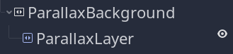

### Lighting and CanvasLayer

In 2D games, we use a combination of `Light2D` and `CanvasModulate` nodes for lighting effects.

`CanvasModulate` only affects its layer, so you need to add one per `CanvasLayer`.

`Light2D` nodes have *Layer Min* and *Layer Max* properties that let you choose the range of layers they should affect. You can use those settings to avoid lighting your user interface and background.